# Forecasting Daily Bike Rental Demand Using Time Series Models

Paul Trimby

2026-03-01

# 1. Introduction

This report presents a time series analysis of daily bike rental demand using data from the Capital Bikeshare system (2011–2012). The objective is to explore underlying patterns in the data and develop a forecasting model capable of predicting future rental demand.

**Data Source:**  
https://archive.ics.uci.edu/ml/datasets/bike+sharing+dataset

**Reference:**  
Fanaee-T, H., & Gama, J. (2013). *Event labeling combining ensemble detectors and background knowledge*. Progress in Artificial Intelligence.

# 2. Data Preparation and Exploration

## 2.1 Load the Data

```r
bike_data <- read_csv("day.csv")
```

## 2.2 Convert to Time Series Format

```r
bike_ts <- bike_data %>%
  mutate(dteday = as.Date(dteday)) %>%
  as_tsibble(index = dteday)

glimpse(bike_ts)
```

```
## Rows: 731
## Columns: 16
## $ instant    <dbl> 1, 2, 3, 4, 5, 6, 7, 8, 9, 10, 11, 12, 13, 14, 15, 16, 17, …
## $ dteday     <date> 2011-01-01, 2011-01-02, 2011-01-03, 2011-01-04, 2011-01-05…
## $ season     <dbl> 1, 1, 1, 1, 1, 1, 1, 1, 1, 1, 1, 1, 1, 1, 1, 1, 1, 1, 1, 1,…
## $ yr         <dbl> 0, 0, 0, 0, 0, 0, 0, 0, 0, 0, 0, 0, 0, 0, 0, 0, 0, 0, 0, 0,…
## $ mnth       <dbl> 1, 1, 1, 1, 1, 1, 1, 1, 1, 1, 1, 1, 1, 1, 1, 1, 1, 1, 1, 1,…
## $ holiday    <dbl> 0, 0, 0, 0, 0, 0, 0, 0, 0, 0, 0, 0, 0, 0, 0, 0, 1, 0, 0, 0,…
## $ weekday    <dbl> 6, 0, 1, 2, 3, 4, 5, 6, 0, 1, 2, 3, 4, 5, 6, 0, 1, 2, 3, 4,…
## $ workingday <dbl> 0, 0, 1, 1, 1, 1, 1, 0, 0, 1, 1, 1, 1, 1, 0, 0, 0, 1, 1, 1,…
## $ weathersit <dbl> 2, 2, 1, 1, 1, 1, 2, 2, 1, 1, 2, 1, 1, 1, 2, 1, 2, 2, 2, 2,…
## $ temp       <dbl> 0.3441670, 0.3634780, 0.1963640, 0.2000000, 0.2269570, 0.20…
## $ atemp      <dbl> 0.3636250, 0.3537390, 0.1894050, 0.2121220, 0.2292700, 0.23…
## $ hum        <dbl> 0.805833, 0.696087, 0.437273, 0.590435, 0.436957, 0.518261,…
## $ windspeed  <dbl> 0.1604460, 0.2485390, 0.2483090, 0.1602960, 0.1869000, 0.08…
## $ casual     <dbl> 331, 131, 120, 108, 82, 88, 148, 68, 54, 41, 43, 25, 38, 54…
## $ registered <dbl> 654, 670, 1229, 1454, 1518, 1518, 1362, 891, 768, 1280, 122…
## $ cnt        <dbl> 985, 801, 1349, 1562, 1600, 1606, 1510, 959, 822, 1321, 126…
```

The dataset contains 731 daily observations, including total rental counts and weather-related variables.

## 2.3 Visual Exploration

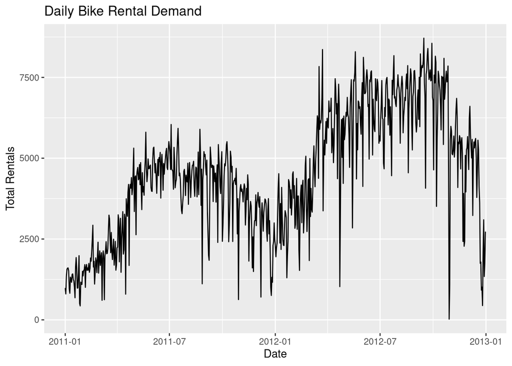

```r
bike_ts %>%
  ggplot(aes(x = dteday, y = cnt)) +
  geom_line() +
  labs(
    title = "Daily Bike Rental Demand",
    x = "Date",
    y = "Total Rentals"
  )
```

The time plot reveals: - An upward trend from 2011 to 2012  
- Clear weekly fluctuations  
- Increasing variability over time

These features suggest the presence of both trend and seasonality.

# 3. Decomposition and Stationarity Assessment

## 3.1 STL Decomposition

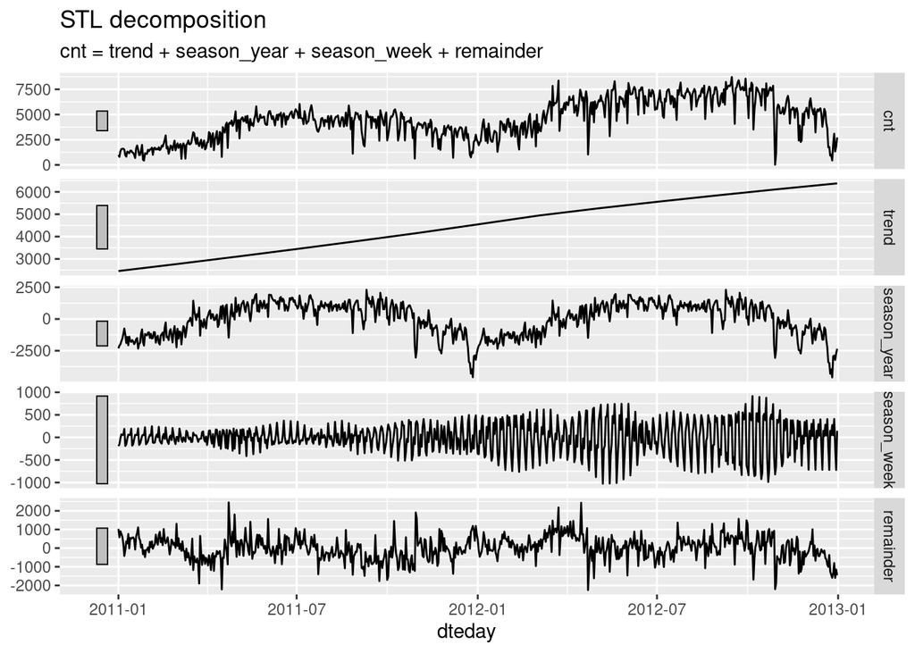

```r
bike_decomp <- bike_ts %>%
  model(STL(cnt))

components(bike_decomp) %>%
  autoplot()
```

## 3.2 Autocorrelation Analysis

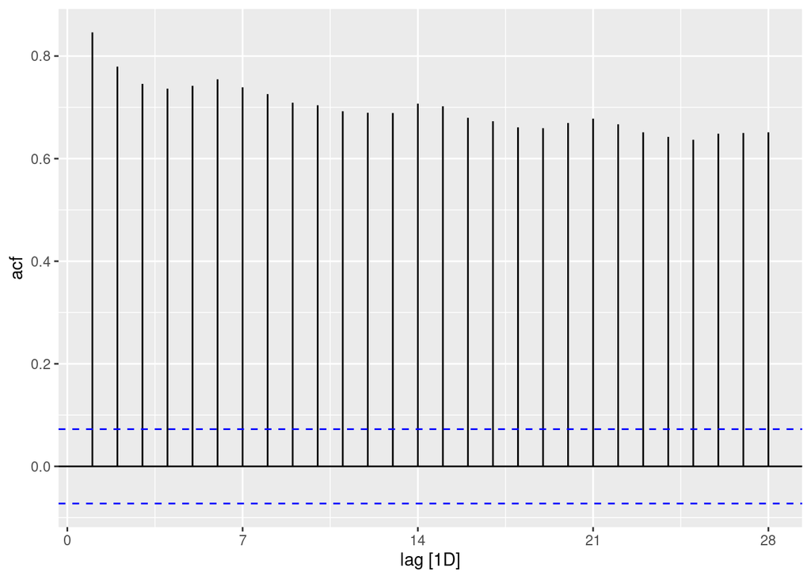

```r
bike_ts %>%
  ACF(cnt) %>%
  autoplot()
```

The ACF plot shows significant autocorrelation, indicating that the series is not stationary and requires differencing before modelling.

# 4. ARIMA Model Fitting

## 4.1 Fit Seasonal ARIMA Model

```r
bike_fit <- bike_ts %>%
  model(ARIMA(cnt))

report(bike_fit)
```

```
## Series: cnt
## Model: ARIMA(1,1,1)(1,0,2)[7]
##
## Coefficients:
##          ar1      ma1    sar1     sma1    sma2
##       0.3612  -0.9005  0.9106  -0.9035  0.0545
## s.e.  0.0427   0.0205  0.0760   0.0865  0.0417
##
## sigma^2 estimated as 844004:  log likelihood=-6014.88
## AIC=12041.75   AICc=12041.87   BIC=12069.31
```

The selected model:

ARIMA(1,1,1)(1,0,2)[7]

Interpretation:

- d = 1 → First differencing removes the upward trend
- [7] → Weekly seasonality (7-day cycle)
- D = 0 → Seasonal pattern is stable and does not require seasonal differencing

Most coefficients are statistically significant, suggesting meaningful short-term and seasonal dependencies.

# 5. Model Diagnostics

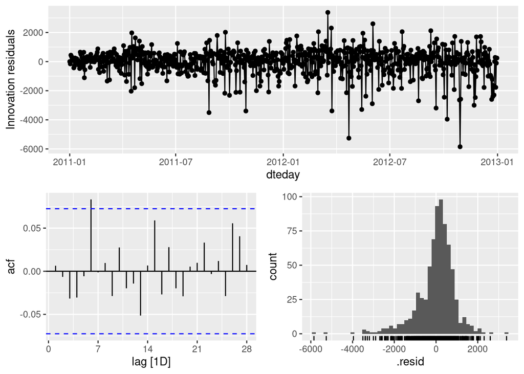

```r
bike_fit %>%
  gg_tsresiduals()
```

This suggests the model residuals behave like white noise and that the ARIMA model adequately captures the structure of the data.

# 6. Forecasting

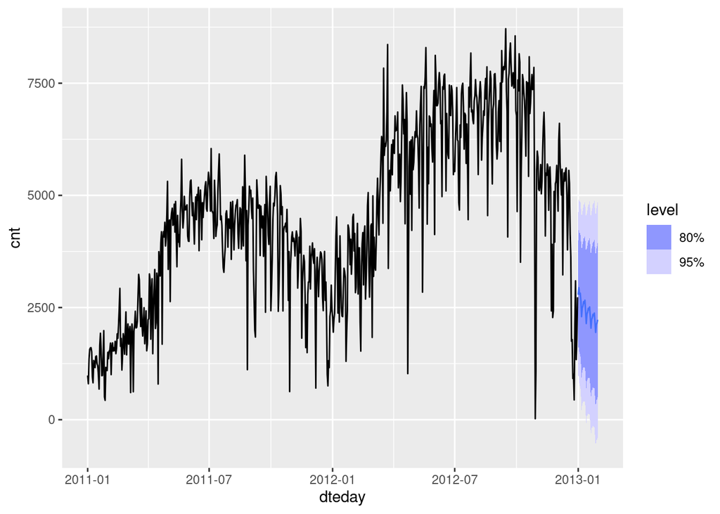

```r
bike_fc <- bike_fit %>%
  forecast(h = "30 days")

autoplot(bike_fc, bike_ts)
```

The 30-day forecast maintains the observed weekly seasonal pattern. Prediction intervals widen over time, reflecting increasing uncertainty in longer-term forecasts.

# 7. Findings and Conclusion

This analysis demonstrates that daily bike rental demand exhibits both trend and strong weekly seasonality.

Residual diagnostics confirm model adequacy, and the generated forecasts provide realistic short-term projections with appropriate uncertainty estimates.

Overall, this project demonstrates a structured and diagnostic-driven time series modelling workflow, from exploration and decomposition to validation and forecasting.